# Final Report Recent

## Introduction

It is a reflection of a nation's dedication to the overall health and happiness of its population and is therefore an essential component of any nation's system of healthcare. In the United States of America, the cost of medical treatment has, for a very long time, been a major source of public anxiety, debate, and investigation. The purpose of this project report is to shed light on the complexities of a system that influences the life of every American by delving into the complexities of national spending on healthcare goods and services within the United States.

## Background

The healthcare system in the United States is one of the most advanced and extensive in the world. It is distinguished by the wide variety of healthcare providers, funding mechanisms, and rules that are in place. The manner in which resources are distributed and the magnitude of expenditures made in this industry have significant bearing on the nation's overall economic security, the state of public health, and the distribution of wealth. Not only is it vital for policymakers to understand the dynamics of healthcare spending, but it is also essential for healthcare professionals, researchers, and the general public to have this understanding.

## Aims and Purposes

The following is an outline of the overarching goals for this project:

1. To conduct an in-depth study on the patterns that have emerged in recent years regarding national spending on healthcare products and services in the United States.
2. To identify the primary drivers, difficulties, and other factors that have an impact on the rise and distribution of healthcare expenditures.
3. To evaluate the influence that spending on healthcare has on the availability of medical care, the results of medical treatment, and the economy as a whole.

## Scope

This project report contains an in-depth analysis of how much money is spent on healthcare in the United States. The analysis covers a wide range of topics, including but not limited to the following:

- Breaking down expenses: analysing how money is spent on different aspects of healthcare, such as hospital care, physician services, medications, and public health efforts.
- Socioeconomic factors: the investigation of the relationship between healthcare spending and socioeconomic indicators such as income, insurance coverage, and discrepancies in access to care.
- Discussion of important healthcare policies and reforms, as well as the consequences these policies and reforms have on spending patterns.

## Methodology

In order to accomplish these goals, we utilised a methodical approach that included the gathering of data from reliable sources, the conduct of statistical analysis, and the perusal of a substantial amount of previous research. We considered the information provided by the Centres for Medicare & Medicaid Services (CMS), the National Health Expenditure Accounts (NHEA), and a number of other reliable sources. In addition, case studies and interviews with subject matter experts gave invaluable qualitative insights.

## Significance

The significance of this research extends far beyond the benefit it provides to academics and policymakers. For the purpose of making educated decisions, influencing healthcare policy, and, ultimately, enhancing the health and well-being of the American people, it is vital to have a comprehensive grasp of national spending on healthcare. We have high hopes that the insights that have been offered in this research will make a meaningful contribution to the discussions that are now taking place around healthcare reform, accessibility, and sustainability.

## Importing the libraries

The following libraries are being adopted for use in our data analysis and visualisation efforts. Dataframes and data cleanup with Pandas. For plotting and rendering, I use Matplotlib and Seaborn.

```python
import pandas as pd
import numpy as np
import matplotlib as plt
import requests, json
```

## Dataset:

This figure provides a rough approximation of the overall sum of money spent on providing medical care each year. The major portion of the funds is allocated to the provision of healthcare services to various individuals. In addition to this, spending goes towards the management of healthcare programmes and private insurance plans, the construction of hospitals and clinics, the acquisition of necessary equipment, the promotion of public health, and the conduct of research in the field of medicine.

Quite a few distinct programmes are responsible for channelling the money that goes into healthcare expenditures. There are private health insurance plans, the money for which comes from the premiums paid by individual Americans as well as the employers of those individuals. In addition, there are government programmes that get funding on all three levels: federal, state, and municipal. In addition, there are subcategories such as school or worksite healthcare, which includes care provided by the school nurse, health screenings financed by the employer, and other on-site medical services.

`LINK` https://usafacts.org/data/topics/people-society/health/healthcare-expenditures/national-spending-on-healthcare-goods-and-services/

```python
health_df= pd.read_excel("national_spending_on_healthcare_goods_and_services_usafacts_transpose.xlsx")
health_df.head(5)
```

|  | Years | National spending on healthcare goods and services ($) | By expenditure | Hospital ($) | Physician and clinical ($) | Dental services ($) | Other professional services ($) | Home health care ($) | Other non-durable medical products ($) | Prescription drug expenditures ($) | ... | Federal ($).2 | State and local ($).2 | Vocational rehabilitation ($) | By type.3 | Federal ($).3 | State and local ($).3 | Other federal programs ($) | Substance Abuse and Mental Health Administration ($) | Other state and local programs ($) | School health ($) |
| --- | --- | --- | --- | --- | --- | --- | --- | --- | --- | --- | --- | --- | --- | --- | --- | --- | --- | --- | --- | --- | --- |
| 0 | 1960 | 27122000000 | 0 | 8985 | 5551 | 1987 | 392 | 57 | 1486 | 2676 | ... | 27 | 89 | 20 | 0 | 12 | 8 | 337 | 0 | 2221 | 122 |
| 1 | 1961 | 29060000000 | 0 | 9777 | 5814 | 2104 | 409 | 61 | 1632 | 2718 | ... | 44 | 127 | 22 | 0 | 14 | 8 | 447 | 0 | 2399 | 140 |
| 2 | 1962 | 31765000000 | 0 | 10432 | 6261 | 2225 | 429 | 65 | 1765 | 3029 | ... | 48 | 133 | 25 | 0 | 15 | 10 | 598 | 0 | 2510 | 147 |
| 3 | 1963 | 34558000000 | 0 | 11507 | 7074 | 2372 | 451 | 69 | 1843 | 3159 | ... | 50 | 150 | 29 | 0 | 18 | 11 | 715 | 0 | 2773 | 143 |
| 4 | 1964 | 38245000000 | 0 | 12501 | 8109 | 2617 | 486 | 75 | 1868 | 3347 | ... | 60 | 159 | 33 | 0 | 20 | 13 | 750 | 0 | 3013 | 151 |

5 rows × 92 columns

## Data Cleansing

- *Description*: Column names were updated to provide more descriptive and meaningful labels.
- *Rationale*: Clear and informative column names improve data readability and comprehension.
- *Procedure*: We reviewed and modified column names to reflect the information they represent.
- *Result*: Column names are now updated and more informative.
- Step 4: Dropping Duplicate Columns
- *Description*: Duplicate columns in the dataset were identified and removed.
- *Rationale*: Duplicate columns add redundancy and can lead to inaccuracies in analysis.
- *Procedure*: We identified duplicate columns by comparing column names and content.
- *Result*: Duplicate columns have been successfully dropped from the dataset.
- Conclusion

The data cleaning process has been completed successfully, and the dataset is now in a more structured, organized, and suitable format for further analysis and modeling. The transposed data, organized categorical columns, renamed columns, and removed duplicate columns enhance the dataset's quality and usability.

- Next Steps

The cleaned dataset will be used for visualizations and further analysis and insights will be derived from this cleaned dataset to support the project objectives. This data cleaning report provides a clear overview of the steps taken to clean the data, along with the rationale for each step and the resulting improvements in data quality. It also outlines the next steps in the data analysis process.

```python
# Uncleaned attributes from the dataset
health_df.columns
```

```
Index(['Years', 'National spending on healthcare goods and services ($)',
       '    By expenditure', '        Hospital ($)',
       '        Physician and clinical ($)', '        Dental services ($)',
       '        Other professional services ($)',
       '        Home health care ($)',
       '        Other non-durable medical products ($)',
       '        Prescription drug expenditures ($)',
       '        Durable medical equipment expenditures ($)',
       '        Nursing care facilities and continuing care retirement communities ($)',
       '        Other health, residential, and personal care expenditures ($)',
       '        Administration expenditures and net cost of health insurance ($)',
       '        State and local administration ($)',
       '        Federal administration ($)',
       '        Net cost of health insurance ($)',
       '        Government public health activities ($)',
       '            By type', '                Federal ($)',
       '                State and local ($)', '        Research ($)',
       '            By type.1', '                Private ($)',
       '                Federal ($).1',
       '                State and local ($).1',
       '        Structures and equipment ($)',
       '        Personal healthcare ($)', '            By source',
       '                Out of pocket ($)',
       '                Private health insurance ($)',
       '                Medicare ($)', '                Medicaid ($)',
       '                    By type', '                        Federal ($)',
       '                        State and local ($)',
       '                Children's Health Insurance Program ($)',
       '                    By type.1',
       '                        Federal ($).1',
       '                        State and local ($).1',
       '                Department of Defense ($)',
       '                Department of Veterans Affiars ($)',
       '                Worksite health care ($)',
       '                Other private revenues ($)',
       '                Indian Health Services ($)',
       '                Workers' compensation ($)',
       '                General assistance ($)',
       '                Maternal and Child Health Program ($)',
       '                    By type.2',
```

[output cut: 21 more lines]

```
       '            Other private revenues ($)',
       '            Indian Health Services ($)',
       '            Workers' compensation ($)',
       '            General assistance ($)',
       '            Maternal and Child Health Program ($)',
       '                By type.2', '                    Federal ($).2',
       '                    State and local ($).2',
       '            Vocational rehabilitation ($)',
       '                By type.3', '                    Federal ($).3',
       '                    State and local ($).3',
       '            Other federal programs ($)',
       '            Substance Abuse and Mental Health Administration ($)',
       '            Other state and local programs ($)',
       '            School health ($)'],
      dtype='object')
```

```python
health_df.columns = health_df.columns.str.strip()
```

```python
## Renaming all the columns by index values
health_df.columns.values[19:21]=['Government public health activities Federal ($)', 'Government public health activities State and local ($)']
health_df.columns.values[23:26]=['Research Private ($)','Research Federal ($)', 'Research State and local ($)']
health_df.columns.values[29:33]=['Personal healthcare Out of pocket($)','Personal healthcare Private health insurance($)', 'Personal healthcare Medicare($)', 'Personal healthcare Medicaid($)']
health_df.columns.values[34:36]=['Personal healthcare Medicaid Federal($)', 'Personal healthcare Medicaid State and local($)']
health_df.columns.values[38:40]=['Personal healthcare Childrens Health Insurance Program Federal($)', 'Personal healthcare Childrens Health Insurance Program State and local($)']
health_df.columns.values[40:48]=['Personal healthcare department of defense($)','Personal healthcare department of veterans affairs($)', 'Personal healthcare worksite healthcare($)', 'Personal healthcare other private revenues($)', 'Personal healthcare Indian health services($)', 'Personal healthcare workers compensation($)', 'Personal healthcare General assistance($)', 'Personal healthcare Maternal and Child Health Program($)']
health_df.columns.values[49:51]=['Personal healthcare Maternal and Child Health Program Federal($)', 'Personal healthcare Maternal and Child Health Program State and local($)']
health_df.columns.values[51:52]=['Personal healthcare Vocational rehabilitation ($)']
health_df.columns.values[53:55]=['Personal healthcare Vocational rehabilitation Federal($)', 'Personal healthcare Vocational rehabilitation State and local($)']
health_df.columns.values[55:59]=['Personal healthcare Other federal programs ($)','Personal healthcare Substance Abuse and Mental Health Administration ($)', 'Personal healthcare Other state and local programs ($)', 'Personal healthcare School health ($)']
health_df.columns.values[60:63] = ['By Source Out of Pocket($)', 'By Source Investment($)', 'By Source Health Insurance($)']
health_df.columns.values[63:66] = ['By Source Health Insurance Private health insurance($)', 'By Source Health Insurance Medicare($)', 'By Source Health Insurance Medicaid($)']
health_df.columns.values[67:69] = ['By Source Health Insurance Medicaid Federal($)', 'By Source Health Insurance Medicaid State and Local($)']
health_df.columns.values[71:73]=['By Source Health Insurance Childrens Health Insurance Program Federal($)', 'By Source Health Insurance Childrens Health Insurance Program State and local($)']
health_df.columns.values[73:81]=['By Source Health Insurance department of defense($)','By Source Health Insurance department of veterans affairs($)', 'By Source Health Insurance worksite healthcare($)', 'By Source Health Insurance other private revenues($)', 'By Source Health Insurance Indian health services($)', 'By Source Health Insurance workers compensation($)', 'By Source Health Insurance General assistance($)', 'By Source Health Insurance Maternal and Child Health Program($)']
health_df.columns.values[82:84]=['By Source Health Insurance Maternal and Child Health Program Federal($)', 'By Source Health Insurance Maternal and Child Health Program State and local($)']
health_df.columns.values[84:85]=['By Source Health Insurance Vocational rehabilitation ($)']
health_df.columns.values[86:88]=['By Source Health Insurance Vocational rehabilitation Federal($)', 'By Source Health Insurance Vocational rehabilitation State and local($)']
health_df.columns.values[88:92]=['By Source Health Insurance Other federal programs ($)','By Source Health Insurance Substance Abuse and Mental Health Administration ($)', 'By Source Health Insurance Other state and local programs ($)', 'By Source Health Insurance School health ($)']


health_df.columns
```

```
Index(['Years', 'National spending on healthcare goods and services ($)',
       'By expenditure', 'Hospital ($)', 'Physician and clinical ($)',
       'Dental services ($)', 'Other professional services ($)',
       'Home health care ($)', 'Other non-durable medical products ($)',
       'Prescription drug expenditures ($)',
       'Durable medical equipment expenditures ($)',
       'Nursing care facilities and continuing care retirement communities ($)',
       'Other health, residential, and personal care expenditures ($)',
       'Administration expenditures and net cost of health insurance ($)',
       'State and local administration ($)', 'Federal administration ($)',
       'Net cost of health insurance ($)',
       'Government public health activities ($)', 'By type',
       'Government public health activities Federal ($)',
       'Government public health activities State and local ($)',
       'Research ($)', 'By type.1', 'Research Private ($)',
       'Research Federal ($)', 'Research State and local ($)',
       'Structures and equipment ($)', 'Personal healthcare ($)', 'By source',
       'Personal healthcare Out of pocket($)',
       'Personal healthcare Private health insurance($)',
       'Personal healthcare Medicare($)', 'Personal healthcare Medicaid($)',
       'By type', 'Personal healthcare Medicaid Federal($)',
       'Personal healthcare Medicaid State and local($)',
       'Children's Health Insurance Program ($)', 'By type.1',
       'Personal healthcare Childrens Health Insurance Program Federal($)',
       'Personal healthcare Childrens Health Insurance Program State and local($)',
       'Personal healthcare department of defense($)',
       'Personal healthcare department of veterans affairs($)',
       'Personal healthcare worksite healthcare($)',
       'Personal healthcare other private revenues($)',
       'Personal healthcare Indian health services($)',
       'Personal healthcare workers compensation($)',
       'Personal healthcare General assistance($)',
       'Personal healthcare Maternal and Child Health Program($)', 'By type.2',
       'Personal healthcare Maternal and Child Health Program Federal($)',
       'Personal healthcare Maternal and Child Health Program State and local($)',
       'Personal healthcare Vocational rehabilitation ($)', 'By type.3',
       'Personal healthcare Vocational rehabilitation Federal($)',
       'Personal healthcare Vocational rehabilitation State and local($)',
       'Personal healthcare Other federal programs ($)',
       'Personal healthcare Substance Abuse and Mental Health Administration ($)',
```

[output cut: 16 more lines]

```
       'By Source Health Insurance Indian health services($)',
       'By Source Health Insurance workers compensation($)',
       'By Source Health Insurance General assistance($)',
       'By Source Health Insurance Maternal and Child Health Program($)',
       'By type.2',
       'By Source Health Insurance Maternal and Child Health Program Federal($)',
       'By Source Health Insurance Maternal and Child Health Program State and local($)',
       'By Source Health Insurance Vocational rehabilitation ($)', 'By type.3',
       'By Source Health Insurance Vocational rehabilitation Federal($)',
       'By Source Health Insurance Vocational rehabilitation State and local($)',
       'By Source Health Insurance Other federal programs ($)',
       'By Source Health Insurance Substance Abuse and Mental Health Administration ($)',
       'By Source Health Insurance Other state and local programs ($)',
       'By Source Health Insurance School health ($)'],
      dtype='object')
```

```python
health_df = health_df.drop(['By type','By expenditure','By type.1','By type.2','By type.3', 'By source'], axis=1)
health_df.columns = health_df.columns.str.upper()
```

```python
health_df.head(10)
```

|  | YEARS | NATIONAL SPENDING ON HEALTHCARE GOODS AND SERVICES ($) | HOSPITAL ($) | PHYSICIAN AND CLINICAL ($) | DENTAL SERVICES ($) | OTHER PROFESSIONAL SERVICES ($) | HOME HEALTH CARE ($) | OTHER NON-DURABLE MEDICAL PRODUCTS ($) | PRESCRIPTION DRUG EXPENDITURES ($) | DURABLE MEDICAL EQUIPMENT EXPENDITURES ($) | ... | BY SOURCE HEALTH INSURANCE MATERNAL AND CHILD HEALTH PROGRAM($) | BY SOURCE HEALTH INSURANCE MATERNAL AND CHILD HEALTH PROGRAM FEDERAL($) | BY SOURCE HEALTH INSURANCE MATERNAL AND CHILD HEALTH PROGRAM STATE AND LOCAL($) | BY SOURCE HEALTH INSURANCE VOCATIONAL REHABILITATION ($) | BY SOURCE HEALTH INSURANCE VOCATIONAL REHABILITATION FEDERAL($) | BY SOURCE HEALTH INSURANCE VOCATIONAL REHABILITATION STATE AND LOCAL($) | BY SOURCE HEALTH INSURANCE OTHER FEDERAL PROGRAMS ($) | BY SOURCE HEALTH INSURANCE SUBSTANCE ABUSE AND MENTAL HEALTH ADMINISTRATION ($) | BY SOURCE HEALTH INSURANCE OTHER STATE AND LOCAL PROGRAMS ($) | BY SOURCE HEALTH INSURANCE SCHOOL HEALTH ($) |
| --- | --- | --- | --- | --- | --- | --- | --- | --- | --- | --- | --- | --- | --- | --- | --- | --- | --- | --- | --- | --- | --- |
| 0 | 1960 | 27122000000 | 8985 | 5551 | 1987 | 392 | 57 | 1486 | 2676 | 740 | ... | 116 | 27 | 89 | 20 | 12 | 8 | 337 | 0 | 2221 | 122 |
| 1 | 1961 | 29060000000 | 9777 | 5814 | 2104 | 409 | 61 | 1632 | 2718 | 765 | ... | 172 | 44 | 127 | 22 | 14 | 8 | 447 | 0 | 2399 | 140 |
| 2 | 1962 | 31765000000 | 10432 | 6261 | 2225 | 429 | 65 | 1765 | 3029 | 910 | ... | 180 | 48 | 133 | 25 | 15 | 10 | 598 | 0 | 2510 | 147 |
| 3 | 1963 | 34558000000 | 11507 | 7074 | 2372 | 451 | 69 | 1843 | 3159 | 901 | ... | 201 | 50 | 150 | 29 | 18 | 11 | 715 | 0 | 2773 | 143 |
| 4 | 1964 | 38245000000 | 12501 | 8109 | 2617 | 486 | 75 | 1868 | 3347 | 1004 | ... | 220 | 60 | 159 | 33 | 20 | 13 | 750 | 0 | 3013 | 151 |
| 5 | 1965 | 41627000000 | 13545 | 8587 | 2819 | 533 | 89 | 1911 | 3715 | 1105 | ... | 244 | 80 | 164 | 41 | 27 | 15 | 831 | 0 | 3392 | 168 |
| 6 | 1966 | 45752000000 | 15298 | 9309 | 2993 | 572 | 108 | 1959 | 3985 | 1242 | ... | 291 | 114 | 176 | 58 | 42 | 16 | 653 | 0 | 3093 | 187 |
| 7 | 1967 | 51186000000 | 17798 | 10448 | 3447 | 608 | 164 | 2015 | 4227 | 1128 | ... | 324 | 142 | 182 | 88 | 66 | 22 | 463 | 0 | 2661 | 215 |
| 8 | 1968 | 58015000000 | 20537 | 11344 | 3707 | 644 | 238 | 2171 | 4742 | 1317 | ... | 377 | 167 | 210 | 115 | 86 | 29 | 489 | 0 | 2944 | 242 |
| 9 | 1969 | 65417000000 | 23367 | 12716 | 4220 | 678 | 272 | 2323 | 5149 | 1512 | ... | 435 | 190 | 244 | 131 | 100 | 31 | 621 | 0 | 3226 | 263 |

10 rows × 79 columns

```python
health_df.columns
```

```
Index(['YEARS', 'NATIONAL SPENDING ON HEALTHCARE GOODS AND SERVICES ($)',
       'HOSPITAL ($)', 'PHYSICIAN AND CLINICAL ($)', 'DENTAL SERVICES ($)',
       'OTHER PROFESSIONAL SERVICES ($)', 'HOME HEALTH CARE ($)',
       'OTHER NON-DURABLE MEDICAL PRODUCTS ($)',
       'PRESCRIPTION DRUG EXPENDITURES ($)',
       'DURABLE MEDICAL EQUIPMENT EXPENDITURES ($)',
       'NURSING CARE FACILITIES AND CONTINUING CARE RETIREMENT COMMUNITIES ($)',
       'OTHER HEALTH, RESIDENTIAL, AND PERSONAL CARE EXPENDITURES ($)',
       'ADMINISTRATION EXPENDITURES AND NET COST OF HEALTH INSURANCE ($)',
       'STATE AND LOCAL ADMINISTRATION ($)', 'FEDERAL ADMINISTRATION ($)',
       'NET COST OF HEALTH INSURANCE ($)',
       'GOVERNMENT PUBLIC HEALTH ACTIVITIES ($)',
       'GOVERNMENT PUBLIC HEALTH ACTIVITIES FEDERAL ($)',
       'GOVERNMENT PUBLIC HEALTH ACTIVITIES STATE AND LOCAL ($)',
       'RESEARCH ($)', 'RESEARCH PRIVATE ($)', 'RESEARCH FEDERAL ($)',
       'RESEARCH STATE AND LOCAL ($)', 'STRUCTURES AND EQUIPMENT ($)',
       'PERSONAL HEALTHCARE ($)', 'PERSONAL HEALTHCARE OUT OF POCKET($)',
       'PERSONAL HEALTHCARE PRIVATE HEALTH INSURANCE($)',
       'PERSONAL HEALTHCARE MEDICARE($)', 'PERSONAL HEALTHCARE MEDICAID($)',
       'PERSONAL HEALTHCARE MEDICAID FEDERAL($)',
       'PERSONAL HEALTHCARE MEDICAID STATE AND LOCAL($)',
       'CHILDREN'S HEALTH INSURANCE PROGRAM ($)',
       'PERSONAL HEALTHCARE CHILDRENS HEALTH INSURANCE PROGRAM FEDERAL($)',
       'PERSONAL HEALTHCARE CHILDRENS HEALTH INSURANCE PROGRAM STATE AND LOCAL($)',
       'PERSONAL HEALTHCARE DEPARTMENT OF DEFENSE($)',
       'PERSONAL HEALTHCARE DEPARTMENT OF VETERANS AFFAIRS($)',
       'PERSONAL HEALTHCARE WORKSITE HEALTHCARE($)',
       'PERSONAL HEALTHCARE OTHER PRIVATE REVENUES($)',
       'PERSONAL HEALTHCARE INDIAN HEALTH SERVICES($)',
       'PERSONAL HEALTHCARE WORKERS COMPENSATION($)',
       'PERSONAL HEALTHCARE GENERAL ASSISTANCE($)',
       'PERSONAL HEALTHCARE MATERNAL AND CHILD HEALTH PROGRAM($)',
       'PERSONAL HEALTHCARE MATERNAL AND CHILD HEALTH PROGRAM FEDERAL($)',
       'PERSONAL HEALTHCARE MATERNAL AND CHILD HEALTH PROGRAM STATE AND LOCAL($)',
       'PERSONAL HEALTHCARE VOCATIONAL REHABILITATION ($)',
       'PERSONAL HEALTHCARE VOCATIONAL REHABILITATION FEDERAL($)',
       'PERSONAL HEALTHCARE VOCATIONAL REHABILITATION STATE AND LOCAL($)',
       'PERSONAL HEALTHCARE OTHER FEDERAL PROGRAMS ($)',
       'PERSONAL HEALTHCARE SUBSTANCE ABUSE AND MENTAL HEALTH ADMINISTRATION ($)',
       'PERSONAL HEALTHCARE OTHER STATE AND LOCAL PROGRAMS ($)',
```

[output cut: 13 more lines]

```
       'BY SOURCE HEALTH INSURANCE OTHER PRIVATE REVENUES($)',
       'BY SOURCE HEALTH INSURANCE INDIAN HEALTH SERVICES($)',
       'BY SOURCE HEALTH INSURANCE WORKERS COMPENSATION($)',
       'BY SOURCE HEALTH INSURANCE GENERAL ASSISTANCE($)',
       'BY SOURCE HEALTH INSURANCE MATERNAL AND CHILD HEALTH PROGRAM($)',
       'BY SOURCE HEALTH INSURANCE MATERNAL AND CHILD HEALTH PROGRAM FEDERAL($)',
       'BY SOURCE HEALTH INSURANCE MATERNAL AND CHILD HEALTH PROGRAM STATE AND LOCAL($)',
       'BY SOURCE HEALTH INSURANCE VOCATIONAL REHABILITATION ($)',
       'BY SOURCE HEALTH INSURANCE VOCATIONAL REHABILITATION FEDERAL($)',
       'BY SOURCE HEALTH INSURANCE VOCATIONAL REHABILITATION STATE AND LOCAL($)',
       'BY SOURCE HEALTH INSURANCE OTHER FEDERAL PROGRAMS ($)',
       'BY SOURCE HEALTH INSURANCE SUBSTANCE ABUSE AND MENTAL HEALTH ADMINISTRATION ($)',
       'BY SOURCE HEALTH INSURANCE OTHER STATE AND LOCAL PROGRAMS ($)',
       'BY SOURCE HEALTH INSURANCE SCHOOL HEALTH ($)'],
      dtype='object')
```

```python
top_10_expen = health_df.columns[2:17]
top_10_expen = top_10_expen.append(health_df.columns[19:20])
top_10_expen = top_10_expen.append(health_df.columns[23:25])
top_10_expen
```

```
Index(['HOSPITAL ($)', 'PHYSICIAN AND CLINICAL ($)', 'DENTAL SERVICES ($)',
       'OTHER PROFESSIONAL SERVICES ($)', 'HOME HEALTH CARE ($)',
       'OTHER NON-DURABLE MEDICAL PRODUCTS ($)',
       'PRESCRIPTION DRUG EXPENDITURES ($)',
       'DURABLE MEDICAL EQUIPMENT EXPENDITURES ($)',
       'NURSING CARE FACILITIES AND CONTINUING CARE RETIREMENT COMMUNITIES ($)',
       'OTHER HEALTH, RESIDENTIAL, AND PERSONAL CARE EXPENDITURES ($)',
       'ADMINISTRATION EXPENDITURES AND NET COST OF HEALTH INSURANCE ($)',
       'STATE AND LOCAL ADMINISTRATION ($)', 'FEDERAL ADMINISTRATION ($)',
       'NET COST OF HEALTH INSURANCE ($)',
       'GOVERNMENT PUBLIC HEALTH ACTIVITIES ($)', 'RESEARCH ($)',
       'STRUCTURES AND EQUIPMENT ($)', 'PERSONAL HEALTHCARE ($)'],
      dtype='object')
```

## Visualization

Individual healthcare is a major expenditure with the ultimate goal of enhancing the public's health and well-being. It covers a wide variety of interventions, from health maintenance to the treatment of specific diseases.

Investment in individual healthcare is motivated by efforts to lessen the effects of chronic illness, eliminate health inequalities, and improve people's quality of life. Early disease identification, better health outcomes, and a healthier population are all results of this industry's focus on expanding access to basic healthcare services.

Influence: Individual healthcare spending has a major effect on public health. They back health improvement projects that make society healthier and more productive, like vaccination drives, easy access to health exams, and illness management plans.

- Sector 2: Hospital

Description: Hospitals are vital components of the healthcare system, offering a wide array of medical services, including emergency care, surgeries, specialized treatments, and inpatient care. Government funding is essential to maintain and upgrade hospital facilities.

Rationale: Hospitals are essential in providing timely and life-saving healthcare services. Government investment in this sector ensures that the healthcare infrastructure can meet the diverse and often urgent healthcare needs of the population. Hospital expenditures encompass staffing, equipment, maintenance, and technology upgrades.

Impact: Adequate funding for hospitals is crucial for reducing wait times, improving patient outcomes, and enhancing the overall healthcare experience. Hospitals play a pivotal role in responding to public health emergencies and ensuring access to critical healthcare services.

- Sector 3: Physician and Clinical Services

Description: This sector includes expenditures related to physician visits, clinical consultations, and routine healthcare services. It aims to ensure that individuals have access to preventive care, early disease detection, and basic healthcare services.

Rationale: Investment in physician and clinical services is driven by the principle that early intervention and preventive care can lead to better health outcomes. Regular check-ups, screenings, and access to primary care physicians are fundamental to maintaining overall health and managing chronic conditions.

Impact: Robust investment in physician and clinical services promotes a culture of proactive healthcare. It empowers individuals to take control of their health and reduces the burden on the healthcare system by preventing avoidable health issues.

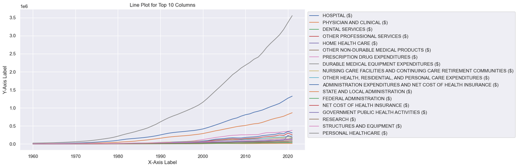

```python
# Set the style of the plot
sns.set(style="darkgrid")

# Create a line plot for the top 10 columns
plt.figure(figsize=(12, 6))  # Optional: Adjust the figure size
for column in top_10_expen:
    sns.lineplot(data=health_df, x='YEARS', y=column, label=column)

# Set labels and title
plt.xlabel('X-Axis Label')
plt.ylabel('Y-Axis Label')
plt.title('Line Plot for Top 10 Columns')

# Add legend outside the plot
plt.legend(loc='upper left', bbox_to_anchor=(1, 1))

# Show the plot
plt.show()
```

## Case Study 1

Private health insurance coverage in the past, especially before the late 1970s, was often limited and came with significant cost-sharing requirements. This means that individuals who had private health insurance still had to pay a substantial portion of their medical expenses out of pocket.

Comprehensive health insurance plans that cover a wide range of medical services with relatively low out-of-pocket costs (e.g., low deductibles and co-payments) were not as common as they are today. Many private plans were more limited in scope, leaving individuals responsible for a larger share of their healthcare expenses. Healthcare costs have been steadily rising for decades. In the years leading up to 1979, healthcare inflation contributed to the overall increase in medical expenses, including out-of-pocket costs.’ Comprehensive employer-sponsored health insurance plans, which are now common, began to gain prominence in the late 1970s and beyond. These plans typically provide better coverage and reduce the financial burden on employees, shifting a significant portion of healthcare costs from out-of-pocket payments to insurance coverage.

Higher out-of-pocket costs placed a significant financial burden on lower-income households. Medical bills could be overwhelming, leading to financial strain, debt, and even bankruptcy. Many lower-income individuals might have postponed or foregone necessary medical care due to the inability to afford it. This delayed access to care could lead to worsened health conditions and poorer health outcomes.

Healthcare disparities, driven by income disparities, were exacerbated. Lower-income individuals faced challenges in accessing timely and quality healthcare services, leading to disparities in health outcomes compared to those with higher incomes. Preventive care, which is essential for early disease detection and management, might have been neglected by lower-income individuals and families due to the focus on acute care needs when they were sick. The higher out-of-pocket costs contributed to inequalities in healthcare. Individuals with greater financial resources could access a broader range of healthcare services without the same level of financial strain. The negative impact of higher out-of-pocket costs on the health and well-being of lower-income individuals was profound. Delayed or skipped medical care could lead to more severe health conditions and a lower quality of life.

In its early years, Medicaid eligibility criteria were more restrictive compared to today. It primarily covered specific groups such as pregnant women, children, and individuals with disabilities. This limited the number of lower-income individuals who could benefit from the program. Despite Medicaid's introduction, there were still significant coverage gaps. Many lower-income adults who didn't fall into the specified categories remained uninsured, as Medicaid did not cover them. This led to continued disparities in healthcare access and outcomes.

In some regions, healthcare providers were reluctant to accept Medicaid patients due to low reimbursement rates. This restricted beneficiaries' access to healthcare services, as they faced challenges in finding willing providers.  
There was a stigma associated with Medicaid, with some viewing it as a program for the very poor. This stigma deterred some eligible individuals from enrolling, further limiting its effectiveness.

The application and enrollment process for Medicaid could be complex, deterring eligible individuals from seeking coverage. Administrative barriers, including paperwork and verification requirements, posed challenges for potential beneficiaries.

Medicaid expansion, which aimed to broaden eligibility to cover more low-income adults, faced political and logistical challenges in some states. This delayed or limited the expansion's impact on increasing coverage. By 2003, Medicaid had undergone several expansions and reforms, significantly increasing the number of eligible beneficiaries. These expansions likely allowed more lower-income individuals and families to enroll in Medicaid, reducing their reliance on out-of-pocket payments for healthcare. Increased public awareness and outreach efforts by state governments and advocacy groups might have encouraged eligible individuals to enroll in Medicaid, ensuring they had access to affordable healthcare services. Economic conditions and changes in income distribution could have contributed to a larger number of individuals becoming eligible for Medicaid. Economic downturns often lead to more people meeting the income criteria for Medicaid.

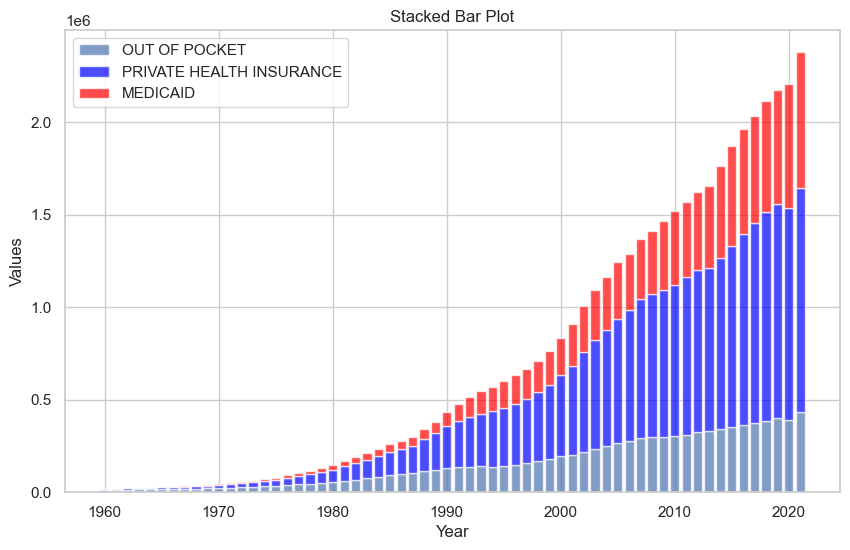

```python
import matplotlib.pyplot as plt
import pandas as pd

# Create a stacked bar plot
plt.figure(figsize=(10, 6))

# Plot each column as a separate bar, stacked
plt.bar(health_df['YEARS'], health_df['BY SOURCE OUT OF POCKET($)'], label='OUT OF POCKET', alpha=0.7)
plt.bar(health_df['YEARS'], health_df['BY SOURCE HEALTH INSURANCE PRIVATE HEALTH INSURANCE($)'], label='PRIVATE HEALTH INSURANCE', alpha=0.7, bottom=health_df['BY SOURCE OUT OF POCKET($)'], color='blue')
plt.bar(health_df['YEARS'], health_df['BY SOURCE HEALTH INSURANCE MEDICAID($)'], label='MEDICAID', alpha=0.7, bottom=health_df['BY SOURCE OUT OF POCKET($)'] + health_df['BY SOURCE HEALTH INSURANCE PRIVATE HEALTH INSURANCE($)'], color='red')

# Add labels and legend
plt.xlabel('Year')
plt.ylabel('Values')
plt.title('Stacked Bar Plot')
plt.legend()

# Show the plot
plt.show()
```

## Case Study 2

Prioritizing Medicare over CHIP may be perceived as neglecting the healthcare needs of a vulnerable population—children from low-income families. Children are dependent on caregivers for their access to healthcare, and underfunding CHIP could result in inadequate coverage for medical services essential for their growth and well-being.

Investing in children's healthcare through CHIP is seen as a preventive strategy. Ensuring children have access to necessary medical care, vaccinations, and screenings can lead to healthier adults with fewer chronic health issues. Underfunding CHIP may lead to missed opportunities for early interventions and preventive care, potentially resulting in more significant healthcare costs later in life.

Underfunding CHIP may exacerbate health disparities among children. Children from low-income families already face barriers to healthcare access, and inadequate funding can further limit their ability to receive timely and necessary medical care. This can perpetuate disparities in health outcomes between socio-economic groups.

Neglecting children's healthcare can have broader public health implications. Unaddressed health issues in childhood can lead to the spread of infectious diseases and long-term health problems, affecting not only individuals but also the wider community.

Children's health is closely linked to their educational attainment and social development. Insufficient funding for CHIP may result in more missed school days due to illness and can limit children's ability to engage in physical and extracurricular activities, affecting their overall development.

Healthier children are more likely to become productive members of the workforce as adults. Underfunding CHIP may lead to a less healthy future workforce, potentially impacting economic productivity and increasing the burden on government-funded healthcare programs.

Some may argue that prioritizing Medicare over CHIP raises ethical questions about equity and the value society places on the health and well-being of children. It may be seen as ethically problematic to underfund a program dedicated to child healthcare when there are alternatives to allocate resources more equitably.

- Political Priorities: Senior Voter Influence: Medicare predominantly serves seniors aged 65 and older. This demographic group tends to have a high voter turnout and political influence. Politicians often prioritize policies that appeal to senior voters, including the funding and expansion of Medicare.

Political Generosity: Senior citizens have historically been a politically active and vocal group, which can lead to politicians allocating more resources to programs that benefit seniors, like Medicare.

Lobbying Efforts: Healthcare industries, including pharmaceutical and medical device companies, often lobby extensively in support of Medicare, as it represents a substantial source of revenue for them. This lobbying can influence policymakers to maintain or expand Medicare funding.

In conclusion, while Medicare is undoubtedly a critical program providing healthcare coverage to seniors and certain disabled individuals, the underfunding of CHIP relative to Medicare can be viewed as problematic due to the potential consequences for children's health, well-being, and long-term societal costs. Critics argue that a balanced and equitable approach to healthcare funding should prioritize preventive care and support for vulnerable populations, including children, to achieve better overall public health and social outcomes.

## Conclusion:

In conclusion, the discussion above has covered several key topics related to healthcare expenditures, government healthcare programs, and funding disparities between programs. Here are the main takeaways from the discussions:

- The United States has one of the highest healthcare expenditures in the world, driven by factors such as the cost of medical services, administrative expenses, and the prevalence of chronic diseases.
- The U.S. government operates several healthcare programs to provide coverage to different population groups. These programs include Medicaid, Medicare, CHIP (Children's Health Insurance Program), and others.
- Medicare primarily serves seniors and certain disabled individuals, while CHIP focuses on providing healthcare coverage to children from low-income families. The allocation of government funds between these programs can be influenced by various factors, including political dynamics and advocacy efforts.
- Medicaid expansion has been a significant policy initiative to increase healthcare coverage for low-income adults. It has expanded eligibility criteria to cover more individuals, reducing the uninsured rate in some states.
- Healthcare disparities, driven by factors like income, race, and geographic location, continue to be a concern in the U.S. These disparities can result in unequal access to healthcare services and poorer health outcomes for marginalized populations.
- Medicaid plays a crucial role in providing healthcare access to lower-income individuals and families. It helps reduce the financial burden of healthcare costs for vulnerable populations.
- Critics express concerns when they observe disparities in funding allocation between healthcare programs, particularly when children's healthcare (CHIP) is underfunded relative to programs like Medicare. They argue that this can have negative consequences for children's health, educational attainment, and long-term healthcare costs.
- Political dynamics, advocacy efforts, and lobbying play significant roles in determining funding levels for healthcare programs. The influence of stakeholders, including seniors, advocacy groups, healthcare industries, and political parties, can shape funding decisions and create disparities.

In summary, the allocation of government funds in healthcare is a complex and multifaceted issue influenced by a variety of political, economic, and social factors. While programs like Medicare are essential for seniors and disabled individuals, concerns arise when funding disparities appear to disadvantage vulnerable populations, such as children covered by CHIP. Advocacy efforts and policy debates aim to address these disparities and ensure equitable access to healthcare services for all segments of the population.